# Part 2 : Looking at Data for the first time

- Cleaning Data
- Visualizing some simple trends to get a good overview of data.

# Background Research

- Looking at potential csv data
- Looking at various trends based using visualization
- Using this information to formulate a concrete research question

```python
import pandas
import numpy
import matplotlib
import matplotlib.pyplot as plt
from pandas.plotting import parallel_coordinates
from sklearn.linear_model import LinearRegression
linear_regressor = LinearRegression()
```

**Displaying All GPA data**

This displays all of the average GPA values for each class, color coded by course number

We can see that this chart is very dense and is hard to read. However it does reveal a few things.

- The first thing we can notice is that there is a smaller distribution of grades as the the level goes up (levels refer to 1000, 2000, 3000, etc).
- Also as classes levels increase we can see that the average GPA is much higher.
- We can also see the density of data points decreases as the x-axis increases (with the exception of classes less than 1000)

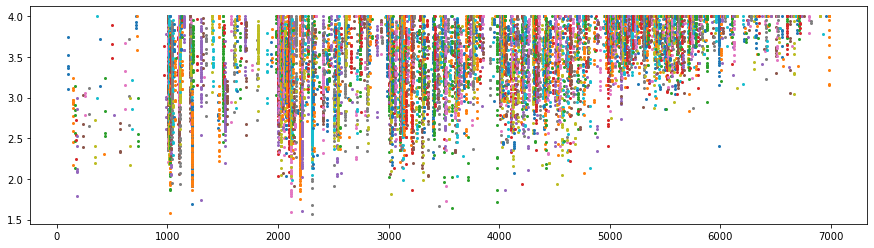

```python
grades = pandas.read_csv('Data/fall-grade-distribution2018-2022.csv')
groups = grades.groupby('Course No.')
f = plt.figure()
f.set_figwidth(15)
f.set_figheight(4)
for name, group in groups:
    plt.plot(group["Course No."], group["GPA"], marker='o', linestyle='', markersize=2, label=name)
```

**Lets try to get some more readable data out of the set**

Here we are looking at the averages of all the GPA in cource number catagories.

We plot these averages out over a 4 years

There is a lot that can be observed here.

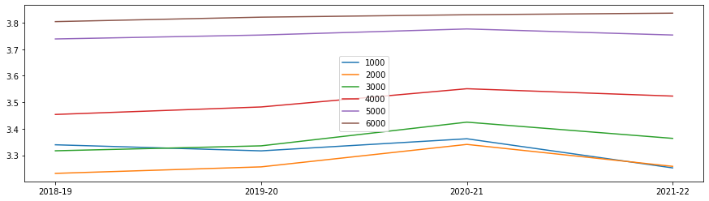

```python
f = plt.figure()
f.set_figwidth(15)
f.set_figheight(4)

# Groups ever 1***, 2****, 3****, etc classes together
for i in range (1,7):

    start = i * 1000
    end = (i + 1) * 1000

    level_df = grades.loc[grades['Course No.'] >= start]
    level_df = level_df.loc[grades['Course No.'] < end]

    # groups the years together and finds the averages from each of the 4 years
    sub_groups = level_df.groupby('Academic Year')

    means =[]
    years = []

    for sub_name, sub_group in sub_groups:
        gpa_averages = sub_group["GPA"].mean()
        means.append(gpa_averages)
        years.append(sub_name)

    # Plots all averages for each year
    plt.plot(years, means, linestyle='solid', markersize=2, label=start)

plt.legend()
```

There is a lot of interesting things happening in this chart

We can add more notoriously difficult classes too.

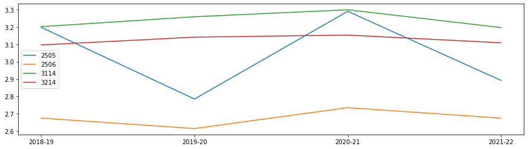

```python
groups = grades.groupby('Course No.')
f = plt.figure()
f.set_figwidth(15)
f.set_figheight(4)
for name, group in groups:
    if name in [3214, 2505, 2506,3114]:
        sub_groups = group.groupby('Academic Year')

        means =[]
        years = []

        for sub_name, sub_group in sub_groups:
            gpa_averages = sub_group["GPA"].mean()
            means.append(gpa_averages)
            years.append(sub_name)
        plt.plot(years, means, linestyle='solid', markersize=2, label=name)

plt.legend()
```

**Some other Ideas to look at**

- Average GPA for each professor (could be a bar graph)
- Grade distribution from year to year
- Look at a single year and graph different professors average GPA
- Maybe a box plot of grades too

# Research Question 1 :

# Are there signs of grade inflation at Virginia Tech?

### Motivation

Grade inflation is an undeniable reality of the US educational system. Over the past couple of decades, GPA for the same courses in bachelor level degrees have risen.

## Figure 1

[figure not shown]

#### Source: https://www.gradeinflation.com/

## Figure 2

[figure not shown]

#### Source: https://www.gradeinflation.com/

### Hypothesis

There is grade inflation at Virginia Tech

### Procedure

1. Get CSV data for grade distribution of classes (Fall, Spring, Summer and Winter) at VT from 2012 to 2022
2. Plot the trend of GPAs
3. Form a conclusion based on the data and visualizations

#### Step 1: Obtaining the Data

```python
All_Grades_Since2012 = pandas.read_csv('Data/All_Grade_Distributions.csv')
df = All_Grades_Since2012.groupby(["Academic Year", "Term","Subject","Course No." ])['GPA',
 'A (%)',
 'A- (%)',
 'B+ (%)',
 'B (%)',
 'B- (%)',
 'C+ (%)',
 'C (%)',
 'C- (%)',
 'D+ (%)',
 'D (%)',
 'D- (%)',
 'F (%)'].mean()
df
```

| Academic Year | Term | Subject | Course No. | GPA | A (%) | A- (%) | B+ (%) | B (%) | B- (%) | C+ (%) | C (%) | C- (%) | D+ (%) | D (%) | D- (%) | F (%) |
| --- | --- | --- | --- | --- | --- | --- | --- | --- | --- | --- | --- | --- | --- | --- | --- | --- |
| 2012-13 | Fall | AAEC | 1005 | 2.490 | 15.7 | 7.55 | 6.85 | 17.30 | 5.90 | 9.1 | 13.15 | 5.45 | 4.5 | 4.5 | 1.9 | 8.2 |
|  |  |  | 1006 | 2.820 | 12.2 | 15.60 | 15.60 | 16.30 | 9.50 | 6.8 | 6.10 | 8.20 | 4.1 | 0.7 | 2.0 | 2.7 |
|  |  |  | 2104 | 3.390 | 54.8 | 0.00 | 0.00 | 33.70 | 0.00 | 0.0 | 8.40 | 0.00 | 0.0 | 1.8 | 0.0 | 1.2 |
|  |  |  | 2434 | 2.780 | 10.7 | 10.70 | 10.70 | 19.60 | 16.10 | 7.1 | 12.50 | 5.40 | 1.8 | 3.6 | 1.8 | 0.0 |
|  |  |  | 2464 | 2.705 | 2.4 | 16.45 | 19.40 | 13.85 | 17.85 | 9.1 | 0.80 | 3.95 | 11.5 | 0.8 | 1.6 | 2.4 |
| ... | ... | ... | ... | ... | ... | ... | ... | ... | ... | ... | ... | ... | ... | ... | ... | ... |
| 2022-23 | Summer I | TA | 3954 | 4.000 | 100.0 | 0.00 | 0.00 | 0.00 | 0.00 | 0.0 | 0.00 | 0.00 | 0.0 | 0.0 | 0.0 | 0.0 |
|  |  | UAP | 3954 | 4.000 | 100.0 | 0.00 | 0.00 | 0.00 | 0.00 | 0.0 | 0.00 | 0.00 | 0.0 | 0.0 | 0.0 | 0.0 |
|  |  |  | 5184 | 4.000 | 100.0 | 0.00 | 0.00 | 0.00 | 0.00 | 0.0 | 0.00 | 0.00 | 0.0 | 0.0 | 0.0 | 0.0 |
|  |  | WGS | 1824 | 3.260 | 55.6 | 11.10 | 11.10 | 0.00 | 0.00 | 11.1 | 0.00 | 0.00 | 0.0 | 0.0 | 0.0 | 11.1 |
|  |  |  | 2204 | 2.540 | 20.0 | 20.00 | 0.00 | 0.00 | 20.00 | 20.0 | 0.00 | 0.00 | 0.0 | 0.0 | 0.0 | 20.0 |

47972 rows × 13 columns

```python
dfGPABySemester= df.groupby(["Academic Year" ])['GPA'].mean()
```

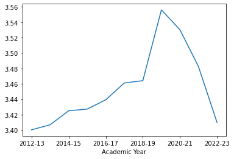

```python
plt= dfGPABySemester.plot.line()
```

#### Step 2: Data Trend Visualization

```
All Departments regression slope = [0.00273992]
```

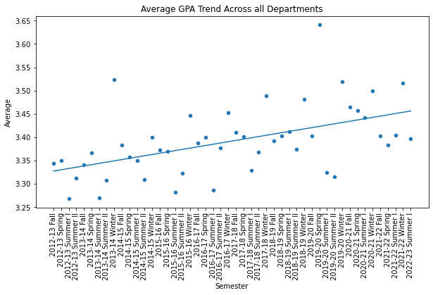

```python
# All Departments
group_by_semester = All_Grades_Since2012.groupby(['Academic Year', 'Term'])

# averages per semester
names = list()
averages = list()
for name, group in group_by_semester:
    names.append('%s %s'%(name[0], name[1]))
    averages.append(numpy.mean(group['GPA']))

semester_averages = [(names[i], averages[i]) for i in range(0, len(names))]
df_semester_averages = pandas.DataFrame(semester_averages, columns=['Semester','Average'])

# linear regression
size = len(averages)
np_indexes = numpy.array(range(0, size))
np_averages = numpy.array(averages)
lm = linear_regressor.fit(np_indexes.reshape(size, 1), np_averages.reshape(size, 1))
df_semester_averages['Predicted'] = lm.predict(np_indexes.reshape(size, 1))
print('All Departments regression slope =', lm.coef_[0])

# plotting
obj = df_semester_averages.plot.scatter(
    title='Average GPA Trend Across all Departments',
y='Average', x='Semester', figsize=(10,5), sharex=False, rot=90)

line = matplotlib.lines.Line2D(np_indexes, df_semester_averages['Predicted'])
obj.add_line(line)
```

```
CS Department regression slope = [0.00865898]
```

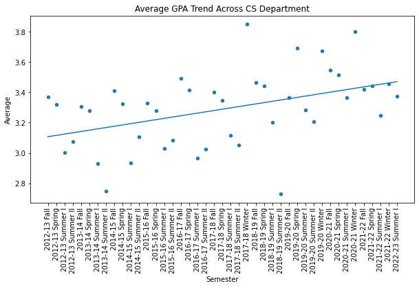

```python
# CS Department
CS_Grades_Since2012 = All_Grades_Since2012[All_Grades_Since2012['Subject']=='CS']
group_by_semester = CS_Grades_Since2012.groupby(['Academic Year', 'Term'])

# averages per semester
names = list()
averages = list()
for name, group in group_by_semester:
    names.append('%s %s'%(name[0], name[1]))
    averages.append(numpy.mean(group['GPA']))

semester_averages = [(names[i], averages[i]) for i in range(0, len(names))]
df_semester_averages = pandas.DataFrame(semester_averages, columns=['Semester','Average'])

# linear regression
size = len(averages)
np_indexes = numpy.array(range(0, size))
np_averages = numpy.array(averages)
lm = linear_regressor.fit(np_indexes.reshape(size, 1), np_averages.reshape(size, 1))
df_semester_averages['Predicted'] = lm.predict(np_indexes.reshape(size, 1))
print('CS Department regression slope =', lm.coef_[0])

# plotting
obj = df_semester_averages.plot.scatter(
    title='Average GPA Trend Across CS Department',
y='Average', x='Semester', figsize=(10,5), sharex=False, rot=90)

line = matplotlib.lines.Line2D(np_indexes, df_semester_averages['Predicted'])
obj.add_line(line)
```

#### Step 3: Conclusion

After performing linear regression to fit a line to the average gpa of each semester over the last decade, we can see that there is a upwards trend across all of the courses at Virginia Tech. When also filtering the course data to only the CS department, there is a larger upwards trend than the all department one. From this we can conclude that there is grade inflation at Virginia Tech, a further question is how does Virginia Tech's inflation compare to that of other schools in the US?

# Other Possible Research Questions

### 1. Comparing the average grades / highs and lows of College of Engineering (CS) vs College of Business (BIT)

##### Prereq:

1. CSV data for CS classes from 2012 to 2022
2. CSV data for BIT classes from 2012 to 2022

##### Hypothesis:

College of Business would have a higher grade average than the College of Engineering

##### Procedure:

1. Obtain the data of classes
2. Plot the distribution of A, B, C and Ds for 4 core BIT classes (BIT 2405, BIT 2406, BIT 3414, BIT 3424)
3. Plot the distribution of A, B, C and Ds for 4 core CS classes (CS 2505, CS 2506, CS 3114, CS 3214)
4. Make a conclusion based on the visualization and data

### 3. Comparing grades of the same CS class between different professors

Question specifics to be added in later parts of the project

### 4. Comparing Virginia Tech's Distribution against other universitys

Question specifics to be added in later parts of the project

# Major Changes to Team Specifics since Part 1

No Major changes to the Team Specifics or Contract We will be working with our original dataset and gathering as many questions as possible regarding our topic.

## Changes to Expect for Phase 3

1. Looking at multiple datasets, merging and comparing.
2. Possible sources for other datasets: (grade distribution for other colleges, national grade distribution data, professor feedback data through RateMyProfessor scraping etc.)

# Part 2 Contributions